[figure not shown]

**User Response POC**

# General EDA

**sample data**

|  | Timestamp | Who are you? | What is "sales enablement" to you (please pick the best match) | Which of these three statements match your opinion of the sales enablement profession? | If you think it is on the rise, please share why you think so? | If you think it is in decline, please share why you think so? | If sales enablement were a business, what business would it be? | Who would be the investors of a sales enablement business? What would they expect? | If sales enablement were to write a letter to shareholders describing how they performed and what they are going to do next year, what would it sound like? | Who is the customer of sales enablement? | What is sales enablement's competition? | Which business strategy should sales enablement follow (pick one)? | If sales enablement were a stock you would: | Optional: What question do you wish we would have asked? | all_fques |
| --- | --- | --- | --- | --- | --- | --- | --- | --- | --- | --- | --- | --- | --- | --- | --- |
| 0 | 2020/03/28 1:40:40 AM AST | Sales enablement leader (you run an enablement... | None of the above match my view well enough | It is on the rise | Because SE as a profession is still ill-define... | noData | An organizational management consultancy. | Investors: Nearly any company, obviously, but ... | This past year saw an improvement in key inter... | The CEO | Possibly a strategy function within an organiz... | Operational excellence (do the blocking and ta... | Buy it (it is undervalued) | noData | Investors: Nearly any company, obviously, but ... |
| 1 | 2020/03/28 8:52:29 AM AST | Sales enablement leader (you run an enablement... | None of the above match my view well enough | In has peaked | noData | noData | Consulting services | Financial services, mutual fund mgmt | We are innovating for the next 10 years | Sales people, channel partners, end customers | Complexity, haste, product vendors | Innovation (develop new products and services,... | Short it (its too highly valued now and going ... | noData | Financial services, mutual fund mgmt # We are ... |

```
Total Questions to be Analyzed: 8
```

|  | ques_name | ques_description |
| --- | --- | --- |
| 0 | investor_and_expectation | Who would be the investors of a sales enablement business? What would they expect? |
| 1 | letter_to_shareholders | If sales enablement were to write a letter to shareholders describing how they performed and what they are going to do next year, what would it sound like? |
| 2 | customer_of_se | Who is the customer of sales enablement? |
| 3 | se_competition | What is sales enablement's competition? |
| 4 | se_business | If sales enablement were a business, what business would it be? |
| 5 | se_is_on_rise | If you think it is on the rise, please share why you think so? |
| 6 | what_ques_to_ask | Optional: What question do you wish we would have asked? |
| 7 | se_is_on_decline | If you think it is in decline, please share why you think so? |

## num words distribution

This plot help in identifying the questions which are highly descriptive in nature.

**Question received descriptive response:**

```
1. se_is_on_rise
2. letter_to_shareholders
```

**Question received brief response:**

```
 1. se_business
 2. customer_of_se
```

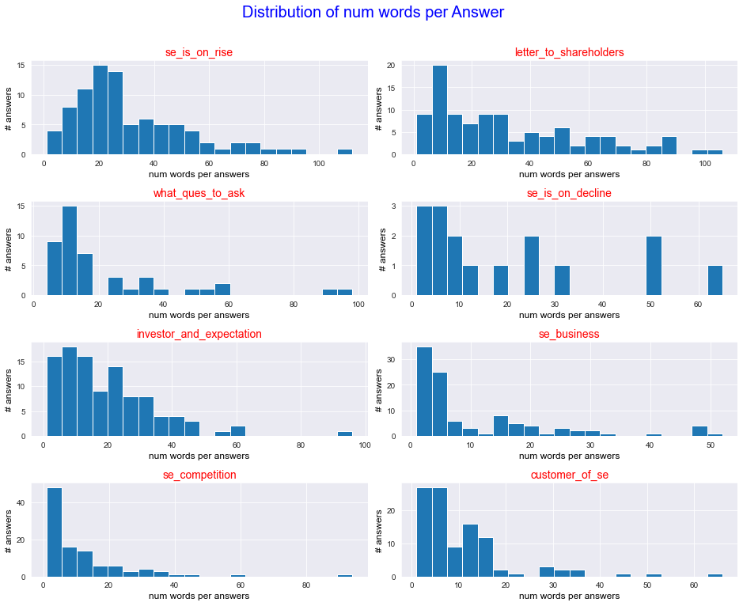

## User Response Sentiment

Center line in the box denotes avg sentiment score for that particular question +1 : highly positive response -1 : highly negative response

- **Overall response is positive (al_fques box)**
- letter_to_shareholder, investor_and_expectation recieved quiet positive response
- se_business, se_is_on_decline, se_competition have the neutral sentiment
- **There is no indication of significant negative sentiment in the user responses**

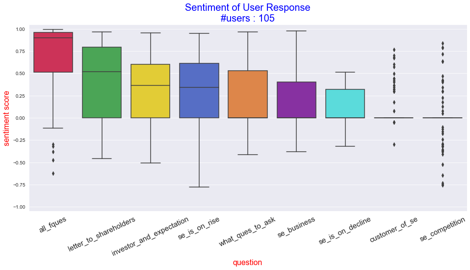

## Sentiment and response length

1. 1st circle : User response.
2. 2nd circle : Questions asked.
3. 3rd circle : sentiment category (pos and neg).
- **size denotes response_length**
- **color denotes sentiment_score**

**Interpretation**

[interactive chart not shown]

# se_competition

What is sales enablement's competition?

## Modelling

### wordcloud

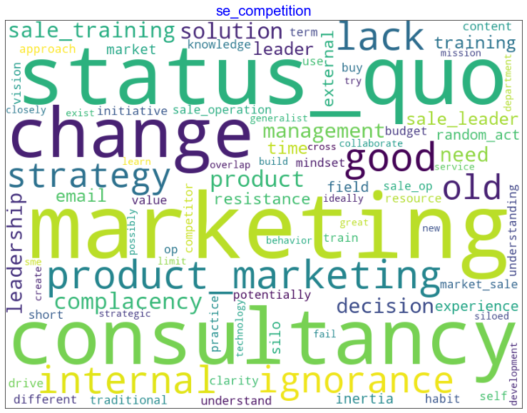

```
_____________________________________________ Modelling completed _____________________________________________
num topics      : 5
coherence score : 0.53 (topN_kw=18)
```

### General Info

**Topic prevalence**

- fraction of users under each topic

[interactive chart not shown]

**Top keywords**

- top keywords under each Topic, sorted by their weight

[interactive chart not shown]

### Statistical info

This graph shows the decorrelation of topics i.e how well separated or distinguishable are topic from each other.

- red color : complete overlap, not favorable
- dark blue : 0 overlap, identified topics are of good quality

[interactive chart not shown]

**2D visualization of topics and associated top keywords**

- each circle denotes one topic
- ideally each topic must lie in a separate quadrant
- size of circle denotes prevalence of a topic (%user per topic)

**keyword plot**

- for a selected topic, topmost keyword is the most important
- blue bar shows overall term freq or in simple words overall importance
- red bar shows estimated term frequency within the selected topic

**How to view ?**

1. Look at the circles i.e topics
   - they must be well separated (ideally in opposite quadrants)
   - bigger circles are more prevalent
2. Click on the topic of interest
   - look at the keyword plot
   - topmost keywords are mostly responsible for the topic assignment
   - red bar should cover most of bar area in top keywords
   - keyword importance should drop sharply

[interactive chart not shown]

### smoke test of topic assignment

Below data shows:

1. top user response match for each topic
2. colored words are the keywords who matched with the assigned topic

[output not shown]

marketing and excess irrelevant marketing content

```
__________________________________________________________________________________________________________________________________
```

status quo and sales leaders that don’t ‘get it” or try to build their own approach and experimentation rather than leaning on leading practices.

```
__________________________________________________________________________________________________________________________________
```

traditional sales approaches

```
__________________________________________________________________________________________________________________________________
```

cro and sales vp's legacy experiences and solutions.,

```
__________________________________________________________________________________________________________________________________
```

ineffective technology solutions.

[output not shown]

"it's nothing new, we do this for 30 years." or in terms iof budget competitors, digital transformation, and cx initiatives

```
__________________________________________________________________________________________________________________________________
```

additional or different initiatives from the field that might not be in synch with the overall mission.

```
__________________________________________________________________________________________________________________________________
```

hr, external training companies

```
__________________________________________________________________________________________________________________________________
```

do it yourself. use outdated metrics to measure and drive your business. up or out.

```
__________________________________________________________________________________________________________________________________
```

our competition is the military who could usurp our training for non-discovery missions. we could be siloed to just those tasks rather than using our insight and initiatives to

have a much bigger impact on the world.

```
__________________________________________________________________________________________________________________________________
Topic-2 : leadership_and_strategy
['consultancy', 'strategy', 'leadership', 'complacency', 'value', 'market_sale', 'fail', 'random_act', 'potentially', 'clarity', 'op', 'sme', 'ideally', 'vision', 'competitor', 'new', 'lack', 'possibly']
```

potentially software, but more likely a leadership team that doesn't see the value

```
__________________________________________________________________________________________________________________________________
```

independent consultants, sales trainers within the organization, sales ops in some cases and do nothing are all competitors.

```
__________________________________________________________________________________________________________________________________
```

in many ways, our competition can be ourselves. without clarity, vision, and socialized expectations, its possible for enablement to take on too much, trip over itself, and fail.

```
__________________________________________________________________________________________________________________________________
```

marketing, sales leadership who want to go it alone

```
__________________________________________________________________________________________________________________________________
```

consulting and random acts of enablement

```
__________________________________________________________________________________________________________________________________
Topic-3 : consultants/LnD
['leader', 'buy', 'strategic', 'lack', 'product', 'sale_operation', 'siloed', 'exist', 'department', 'need', 'decision', 'overlap', 'cross', 'closely', 'great', 'understand', 'understanding', 'time']
```

not quite sure i understand. possibly sales operations? although we are closely aligned there is some overlap in practice which makes the line of ownership blur, and leads to competition.

```
__________________________________________________________________________________________________________________________________
```

the sales reps and leaders disinclined to buy into enablement's strategic programming. also the lone-wold reps who demand to do it their own way.

```
__________________________________________________________________________________________________________________________________
```

lack of time

```
__________________________________________________________________________________________________________________________________
```

the competition sales enablement faces is a lack of understanding of what it is, it's mechanisms, and how it can benefit the business as a whole.

```
__________________________________________________________________________________________________________________________________
```

siloed department leaders protecting existing budgets and “how they have always done it”

```
__________________________________________________________________________________________________________________________________
Topic-4 : change_resistance/training/status_quo
['change', 'product_marketing', 'status_quo', 'good', 'management', 'internal', 'old', 'resistance', 'sale_training', 'silo', 'resource', 'limit', 'mindset', 'email', 'train', 'generalist', 'knowledge', 'self']
```

human beings- resistance to change, rigid mindsets, getting to a place of "expanding self-imposed limits/parameters"

```
__________________________________________________________________________________________________________________________________
```

old methods - email sharing, rogue portals

```
__________________________________________________________________________________________________________________________________
```

generalists within sales ops/orgs.

```
__________________________________________________________________________________________________________________________________
```

status quo and the sales training business

```
__________________________________________________________________________________________________________________________________
```

the sales force, old school and adverse to change.

```
__________________________________________________________________________________________________________________________________
```

# se_business

If sales enablement were a business, what business would it be?

## Modelling

### wordcloud

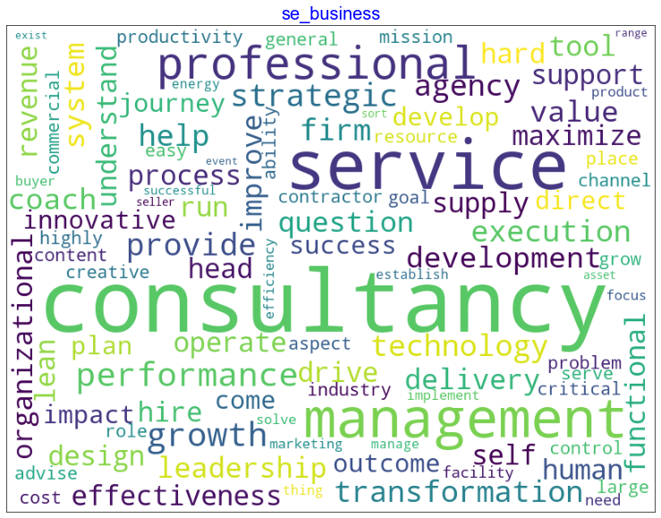

```
_____________________________________________ Modelling completed _____________________________________________
num topics      : 5
coherence score : 0.47 (topN_kw=18)
```

### General Info

**Topic prevalence**

- fraction of users under each topic

[interactive chart not shown]

**Top keywords**

- top keywords under each Topic, sorted by their weight

[interactive chart not shown]

### Statistical info

This graph shows the decorrelation of topics i.e how well separated or distinguishable are topic from each other.

- red color : complete overlap, not favorable
- dark blue : 0 overlap, identified topics are of good quality

[interactive chart not shown]

**2D visualization of topics and associated top keywords**

- each circle denotes one topic
- ideally each topic must lie in a separate quadrant
- size of circle denotes prevalence of a topic (%user per topic)

**keyword plot**

- for a selected topic, topmost keyword is the most important
- blue bar shows overall term freq or in simple words overall importance
- red bar shows estimated term frequency within the selected topic

**How to view ?**

1. Look at the circles i.e topics
   - they must be well separated (ideally in opposite quadrants)
   - bigger circles are more prevalent
2. Click on the topic of interest
   - look at the keyword plot
   - topmost keywords are mostly responsible for the topic assignment
   - red bar should cover most of bar area in top keywords
   - keyword importance should drop sharply

[interactive chart not shown]

### smoke test of topic assignment

Below data shows:

1. top user response match for each topic
2. colored words are the keywords who matched with the assigned topic

```
Ques : se_business

Topic-0 : innovative/creative/adding_value
['solve', 'problem', 'innovative', 'leadership', 'drive', 'head', 'value', 'hard', 'channel', 'successful', 'journey', 'develop', 'highly', 'role', 'buyer', 'aspect', 'cost', 'content']
```

innovative think tank that truly solves problem with speed

```
__________________________________________________________________________________________________________________________________
```

a business that enables sales teams and their customers through out the buyers journey, ending in value creation.

```
__________________________________________________________________________________________________________________________________
```

aimed at driving the largest channel revenue & booking contribution @ the lowest cost

```
__________________________________________________________________________________________________________________________________
```

linkedin. expensive and brings a ton of value but hard to quantify at times.

```
__________________________________________________________________________________________________________________________________
```

sales enablement should be in the business of developing top talent in all aspects of the customer engagement.

```
__________________________________________________________________________________________________________________________________
Topic-1 : strategic_critical_roles
['strategic', 'resource', 'performance', 'critical', 'execution', 'system', 'come', 'understand', 'run', 'contractor', 'general', 'facility', 'range', 'exist', 'event', 'functional', 'lean', 'thing']
```

it would be a supplier in a large system, but one that does supply many things. amazon immediately comes to mind.

```
__________________________________________________________________________________________________________________________________
```

oil e&p (exploration and production) you figure out where there might be opportunity, run some tests to figure out if it's worth your time, if so - invest time &

energy, and then pump til it's dry and move on. maybe come back and do some frac'ing if wells run dry.

```
__________________________________________________________________________________________________________________________________
```

general contractor, therapist, ems - not sure.

```
__________________________________________________________________________________________________________________________________
```

a startup- fast paced, running lean, trying to serve multiple purposes all at once

```
__________________________________________________________________________________________________________________________________
```

a full-service licensed general contractor serving corporate america. providing services ranging from basic efficiencies (energy / use of resources) to renovation of existing facilities to full restoration after a critical

event (merger / acquisition / covid19). cross functional consulting - a steward of resource that drives positive outcomes.

```
__________________________________________________________________________________________________________________________________
Topic-2 : professional_development/
['professional', 'tool', 'process', 'design', 'technology', 'coach', 'marketing', 'agency', 'focus', 'development', 'human', 'place', 'transformation', 'maximize', 'question', 'need', 'support', 'ability']
```

fedex - putting together the people, process and technology to deliverer what's needed at the right place at the right time during the sales process. .

```
__________________________________________________________________________________________________________________________________
```

professional development, coaching, almost like a marketing department for sales professionals

```
__________________________________________________________________________________________________________________________________
```

professional development

```
__________________________________________________________________________________________________________________________________
```

mission control for a space launch

```
__________________________________________________________________________________________________________________________________
```

maximizing human potential

```
__________________________________________________________________________________________________________________________________
Topic-3 : service_business/help_business_growth
['operate', 'help', 'success', 'grow', 'establish', 'hire', 'asset', 'sort', 'seller', 'direct', 'impact', 'advise', 'easy', 'commercial', 'industry', 'plan', 'problem', 'manage']
```

anderson / e&y/ pwc... like the big 5 accounting firms on the 80s and 90s. sales enablement has a direct impact on the success of the company.

```
__________________________________________________________________________________________________________________________________
```

grocery delivery. weekly goodness in easy to handle trays - arriving at a planned time l.

```
__________________________________________________________________________________________________________________________________
```

ha. this is my favorite... so easy! sales enablement is like preventative care - your gym membership, your personal trainer, your diet, your fitness goals. of course, you can have

none of those and still live. but if you focus on them, you're in preventive care mode and likely to live a longer healthier life. on the flip side, those

that let themselves go.... well they're off to the emergency ward. in the er there are specialists of all sorts - immediate diagnosis of all vitals, intensive care, stabilization mode

of the patient. then once vitals are established it's off to the specialists cardiology (sales coaching), radiology (sales asset management), orthopedics (sales tools etc)... you get the drift. when you've

isolated the problem you should go to a specialist who can operate and advise, then pass back to wards (generalist enablement practitioner)

```
__________________________________________________________________________________________________________________________________
```

it would be in the business of helping humans be better prepared and more engaged in a growing digital world

```
__________________________________________________________________________________________________________________________________
```

operating excellence

```
__________________________________________________________________________________________________________________________________
Topic-4 : management/consultancy
['consultancy', 'service', 'management', 'provide', 'growth', 'improve', 'firm', 'outcome', 'effectiveness', 'productivity', 'efficiency', 'product', 'organizational', 'advise', 'strategic', 'highly', 'performance', 'drive']
```

sales growth & productivity products and services

```
__________________________________________________________________________________________________________________________________
```

consulting. service. change management

```
__________________________________________________________________________________________________________________________________
```

an organizational management consultancy.

```
__________________________________________________________________________________________________________________________________
```

business consulting firm that advises on and provides services plus technology to improve business outcomes.

```
__________________________________________________________________________________________________________________________________
```

management consulting

```
__________________________________________________________________________________________________________________________________
```